# README

Silas Principe

2023-04-18

# MPA Europe - Definition of the study area

[figure not shown]

OBIS/UNESCO is contributing with the MPA Europe project by predicting the potential distribution of species and biogenic habitats, an essential information to map the locations that would maximize the conservation of species and ecosystems. You can know more about the [MPA Europe project here](https://mpa-europe.eu) and [learn more about the contribution of OBIS here](https://obis.org/2023/03/10/MPA_europe/).

## Defining the study area

Here is the code used to generate the shapefiles of the study area, to ensure consistency between partners’ tasks. There are two files on the **codes** folder: `study_area.R` is the main file to produce the study area (see steps documented below); `generate_variants.R` is used to generate other shapefiles of interest (e.g. a version projected to a better CRS for plotting).

In progress:

- Create an expanded study area that will be the base for the SDMs (that is, considering nearby areas where species may also be present).

## How the shapefile was generated?

The study area was defined in the MPA Europe project, but a coherent working shapefile was lacking. We generated one by first downloading the Marineregions IHO/EEZ intersection map (https://www.marineregions.org/downloads.php#ihoeez), so we could filter by both EEZ and IHO seas, and an Europe map from NaturalEarth (https://www.naturalearthdata.com).

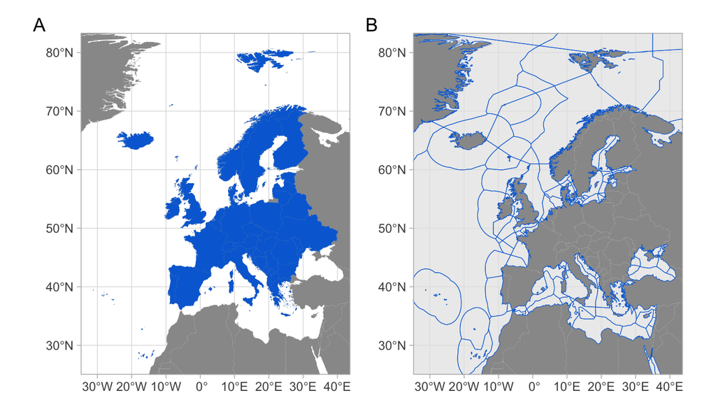

1. Europe region selected for the study. (B) IHO/EEZ intersection map used to obtain the study area.

Thus, we intersected both areas to obtain those EEZ correspondent to the study area. We further removed/added some areas manually to reach the final result.

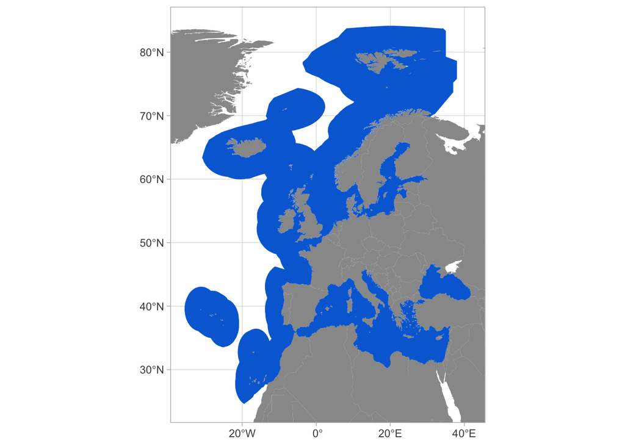

The final study area for the MPA Europe project.